# Actividad_grupal

Lander Ortiz Crespo, Gorka Sudupe Ormaetxea, Óscar Jiménez Osuna

14/2/2021

Leer archivo con R para convertirlo a dataframe.

```r
library(dplyr)
library(tidyverse)
df <- read.table("C:/attrition_data.csv", header=T, sep="," , dec=".")
head(df)
```

```
##   ï..Age Attrition    BusinessTravel DailyRate             Department
## 1     41       Yes     Travel_Rarely      1102                  Sales
## 2     49        No Travel_Frequently       279 Research & Development
## 3     37       Yes     Travel_Rarely      1373 Research & Development
## 4     33        No Travel_Frequently      1392 Research & Development
## 5     27        No     Travel_Rarely       591 Research & Development
## 6     32        No Travel_Frequently      1005 Research & Development
##   DistanceFromHome Education EducationField EmployeeCount EmployeeNumber
## 1                1         2  Life Sciences             1              1
## 2                8         1  Life Sciences             1              2
## 3                2         2          Other             1              4
## 4                3         4  Life Sciences             1              5
## 5                2         1        Medical             1              7
## 6                2         2  Life Sciences             1              8
##   EnvironmentSatisfaction Gender HourlyRate JobInvolvement JobLevel
```

[output cut: 41 more lines]

Cambiamos el nombre la varible Age

```r
names(df)[1] = "Age"
```

Observar el comportamiento de cada variable, su coherencia, si se ha leído con el tipo de dato adecuado para el análisis, etc.

Estructura del dataframe. Cantidad de filas y columnas.

```r
dim(df)
```

```
## [1] 1470   35
```

```r
str(df)
```

```
## 'data.frame':    1470 obs. of  35 variables:
##  $ Age                     : int  41 49 37 33 27 32 59 30 38 36 ...
##  $ Attrition               : Factor w/ 2 levels "No","Yes": 2 1 2 1 1 1 1 1 1 1 ...
##  $ BusinessTravel          : Factor w/ 3 levels "Non-Travel","Travel_Frequently",..: 3 2 3 2 3 2 3 3 2 3 ...
##  $ DailyRate               : int  1102 279 1373 1392 591 1005 1324 1358 216 1299 ...
##  $ Department              : Factor w/ 3 levels "Human Resources",..: 3 2 2 2 2 2 2 2 2 2 ...
##  $ DistanceFromHome        : int  1 8 2 3 2 2 3 24 23 27 ...
##  $ Education               : int  2 1 2 4 1 2 3 1 3 3 ...
##  $ EducationField          : Factor w/ 6 levels "Human Resources",..: 2 2 5 2 4 2 4 2 2 4 ...
##  $ EmployeeCount           : int  1 1 1 1 1 1 1 1 1 1 ...
##  $ EmployeeNumber          : int  1 2 4 5 7 8 10 11 12 13 ...
##  $ EnvironmentSatisfaction : int  2 3 4 4 1 4 3 4 4 3 ...
##  $ Gender                  : Factor w/ 2 levels "Female","Male": 1 2 2 1 2 2 1 2 2 2 ...
##  $ HourlyRate              : int  94 61 92 56 40 79 81 67 44 94 ...
##  $ JobInvolvement          : int  3 2 2 3 3 3 4 3 2 3 ...
```

[output cut: 21 more lines]

Analizar la distribución de las variables, buscando valores perdidos (faltantes) o anómalos, incoherencias, valores extremos, etc. Basta un análisis simplificado, no es necesario pormenorizar.

Valores faltantes o perdidos.

```r
sum(is.na(df))
```

```
## [1] 0
```

names() nos permite ver los nombres de las columnas

```r
names(df)
```

```
##  [1] "Age"                      "Attrition"
##  [3] "BusinessTravel"           "DailyRate"
##  [5] "Department"               "DistanceFromHome"
##  [7] "Education"                "EducationField"
##  [9] "EmployeeCount"            "EmployeeNumber"
## [11] "EnvironmentSatisfaction"  "Gender"
## [13] "HourlyRate"               "JobInvolvement"
## [15] "JobLevel"                 "JobRole"
## [17] "JobSatisfaction"          "MaritalStatus"
## [19] "MonthlyIncome"            "MonthlyRate"
## [21] "NumCompaniesWorked"       "Over18"
## [23] "OverTime"                 "PercentSalaryHike"
## [25] "PerformanceRating"        "RelationshipSatisfaction"
## [27] "StandardHours"            "StockOptionLevel"
## [29] "TotalWorkingYears"        "TrainingTimesLastYear"
## [31] "WorkLifeBalance"          "YearsAtCompany"
## [33] "YearsInCurrentRole"       "YearsSinceLastPromotion"
## [35] "YearsWithCurrManager"
```

Estudiar los rangos de las variables en el caso de variables contínuas, número de categorías diferentes en el caso de variables categóricas, medidas de dispersión (medias, desviaciones, etc., incluido el cálculo de dichas medidas agrupando en función de una o varias variable categóricas que puedan definir grupos).

Calculamos las correlaciones entre los diferentes atributos.

```r
head(df)
```

```
##   Age Attrition    BusinessTravel DailyRate             Department
## 1  41       Yes     Travel_Rarely      1102                  Sales
## 2  49        No Travel_Frequently       279 Research & Development
## 3  37       Yes     Travel_Rarely      1373 Research & Development
## 4  33        No Travel_Frequently      1392 Research & Development
## 5  27        No     Travel_Rarely       591 Research & Development
## 6  32        No Travel_Frequently      1005 Research & Development
##   DistanceFromHome Education EducationField EmployeeCount EmployeeNumber
## 1                1         2  Life Sciences             1              1
## 2                8         1  Life Sciences             1              2
## 3                2         2          Other             1              4
## 4                3         4  Life Sciences             1              5
## 5                2         1        Medical             1              7
## 6                2         2  Life Sciences             1              8
##   EnvironmentSatisfaction Gender HourlyRate JobInvolvement JobLevel
```

[output cut: 41 more lines]

```r
df_num <- select(df, Age, DailyRate, DistanceFromHome, Education, EmployeeCount, EmployeeNumber, EnvironmentSatisfaction, HourlyRate, JobInvolvement, JobLevel, JobSatisfaction, MonthlyIncome, MonthlyRate, NumCompaniesWorked, PercentSalaryHike, PerformanceRating, RelationshipSatisfaction, StockOptionLevel, TotalWorkingYears, TrainingTimesLastYear, WorkLifeBalance, YearsAtCompany, YearsInCurrentRole, YearsSinceLastPromotion, YearsWithCurrManager )

cor(df_num)
```

```
##                                   Age     DailyRate DistanceFromHome
## Age                       1.000000000  0.0106609426     -0.001686120
## DailyRate                 0.010660943  1.0000000000     -0.004985337
## DistanceFromHome         -0.001686120 -0.0049853374      1.000000000
## Education                 0.208033731 -0.0168064332      0.021041826
## EmployeeCount                      NA            NA               NA
## EmployeeNumber           -0.010145467 -0.0509904337      0.032916407
## EnvironmentSatisfaction   0.010146428  0.0183548543     -0.016075327
## HourlyRate                0.024286543  0.0233814215      0.031130586
## JobInvolvement            0.029819959  0.0461348740      0.008783280
## JobLevel                  0.509604228  0.0029663349      0.005302731
## JobSatisfaction          -0.004891877  0.0305710078     -0.003668839
## MonthlyIncome             0.497854567  0.0077070589     -0.017014445
## MonthlyRate               0.028051167 -0.0321816015      0.027472864
## NumCompaniesWorked        0.299634758  0.0381534343     -0.029250804
## PercentSalaryHike         0.003633585  0.0227036775      0.040235377
## PerformanceRating         0.001903896  0.0004732963      0.027109618
## RelationshipSatisfaction  0.053534720  0.0078460310      0.006557475
## StockOptionLevel          0.037509712  0.0421427964      0.044871999
## TotalWorkingYears         0.680380536  0.0145147387      0.004628426
## TrainingTimesLastYear    -0.019620819  0.0024525427     -0.036942234
## WorkLifeBalance          -0.021490028 -0.0378480510     -0.026556004
## YearsAtCompany            0.311308770 -0.0340547676      0.009507720
## YearsInCurrentRole        0.212901056  0.0099320150      0.018844999
## YearsSinceLastPromotion   0.216513368 -0.0332289848      0.010028836
## YearsWithCurrManager      0.202088602 -0.0263631782      0.014406048
##                             Education EmployeeCount EmployeeNumber
## Age                       0.208033731            NA   -0.010145467
## DailyRate                -0.016806433            NA   -0.050990434
## DistanceFromHome          0.021041826            NA    0.032916407
## Education                 1.000000000            NA    0.042070093
## EmployeeCount                      NA             1             NA
## EmployeeNumber            0.042070093            NA    1.000000000
## EnvironmentSatisfaction  -0.027128313            NA    0.017620802
## HourlyRate                0.016774829            NA    0.035179212
## JobInvolvement            0.042437634            NA   -0.006887923
## JobLevel                  0.101588886            NA   -0.018519194
## JobSatisfaction          -0.011296117            NA   -0.046246735
## MonthlyIncome             0.094960677            NA   -0.014828516
## MonthlyRate              -0.026084197            NA    0.012648229
```

[output cut: 205 more lines]

```
## JobSatisfaction                 -0.0276562139
## MonthlyIncome                    0.3440788833
## MonthlyRate                     -0.0367459053
## NumCompaniesWorked              -0.1103191554
## PercentSalaryHike               -0.0119852485
## PerformanceRating                0.0228271689
## RelationshipSatisfaction        -0.0008674968
## StockOptionLevel                 0.0246982266
## TotalWorkingYears                0.4591883971
## TrainingTimesLastYear           -0.0040955260
## WorkLifeBalance                  0.0027594402
## YearsAtCompany                   0.7692124251
## YearsInCurrentRole               0.7143647616
## YearsSinceLastPromotion          0.5102236358
## YearsWithCurrManager             1.0000000000
```

Vamos a escoger los siguientes atributos dados el grado de correlación que tienen con el resto:

MonthlyIncome, JobLevel, NumCompaniesWorked, YearsAtCompany, YearsSinceLastPromotion, YearsWithCurrManager

Guardamos en otro dataset las columnas que vamos a utilizar (las anteriores más algunas categóricas).

```r
datos <- select(df, Attrition, BusinessTravel, Gender, JobLevel, MonthlyIncome, NumCompaniesWorked, YearsAtCompany, YearsSinceLastPromotion, YearsWithCurrManager)
head(datos)
```

```
##   Attrition    BusinessTravel Gender JobLevel MonthlyIncome NumCompaniesWorked
## 1       Yes     Travel_Rarely Female        2          5993                  8
## 2        No Travel_Frequently   Male        2          5130                  1
## 3       Yes     Travel_Rarely   Male        1          2090                  6
## 4        No Travel_Frequently Female        1          2909                  1
## 5        No     Travel_Rarely   Male        1          3468                  9
## 6        No Travel_Frequently   Male        1          3068                  0
##   YearsAtCompany YearsSinceLastPromotion YearsWithCurrManager
## 1              6                       0                    5
## 2             10                       1                    7
## 3              0                       0                    0
## 4              8                       3                    0
## 5              2                       2                    2
## 6              7                       3                    6
```

Distintos valores de los atributos categóricos.

```r
unique(datos$Attrition)
```

```
## [1] Yes No
## Levels: No Yes
```

```r
unique(datos$BusinessTravel)
```

```
## [1] Travel_Rarely     Travel_Frequently Non-Travel
## Levels: Non-Travel Travel_Frequently Travel_Rarely
```

```r
unique(datos$Gender)
```

```
## [1] Female Male
## Levels: Female Male
```

```r
unique(datos$JobLeve)
```

```
## [1] 2 1 3 4 5
```

Medidas de dispersión

Resumen de características de dataframe.

Observamos que el datset está muy desbalanceado si tenemos en cuenta nuestro atributo clase (Attrition).

```r
summary(datos)
```

```
##  Attrition            BusinessTravel    Gender       JobLevel
##  No :1233   Non-Travel       : 150   Female:588   Min.   :1.000
##  Yes: 237   Travel_Frequently: 277   Male  :882   1st Qu.:1.000
##             Travel_Rarely    :1043                Median :2.000
##                                                   Mean   :2.064
##                                                   3rd Qu.:3.000
##                                                   Max.   :5.000
##  MonthlyIncome   NumCompaniesWorked YearsAtCompany   YearsSinceLastPromotion
##  Min.   : 1009   Min.   :0.000      Min.   : 0.000   Min.   : 0.000
##  1st Qu.: 2911   1st Qu.:1.000      1st Qu.: 3.000   1st Qu.: 0.000
##  Median : 4919   Median :2.000      Median : 5.000   Median : 1.000
##  Mean   : 6503   Mean   :2.693      Mean   : 7.008   Mean   : 2.188
##  3rd Qu.: 8379   3rd Qu.:4.000      3rd Qu.: 9.000   3rd Qu.: 3.000
##  Max.   :19999   Max.   :9.000      Max.   :40.000   Max.   :15.000
##  YearsWithCurrManager
##  Min.   : 0.000
##  1st Qu.: 2.000
##  Median : 3.000
##  Mean   : 4.123
##  3rd Qu.: 7.000
##  Max.   :17.000
```

Medidas de tendencia central (moda, medias y medianas).

Agrupemos por Attrition y por las diferentes variables ordinales.

```r
by(datos$MonthlyIncome,(datos$Attrition),FUN=summary)
```

```
## (datos$Attrition): No
##    Min. 1st Qu.  Median    Mean 3rd Qu.    Max.
##    1051    3211    5204    6833    8834   19999
## ------------------------------------------------------------
## (datos$Attrition): Yes
##    Min. 1st Qu.  Median    Mean 3rd Qu.    Max.
##    1009    2373    3202    4787    5916   19859
```

```r
by(datos$NumCompaniesWorked,(datos$Attrition),FUN=summary)
```

```
## (datos$Attrition): No
##    Min. 1st Qu.  Median    Mean 3rd Qu.    Max.
##   0.000   1.000   2.000   2.646   4.000   9.000
## ------------------------------------------------------------
## (datos$Attrition): Yes
##    Min. 1st Qu.  Median    Mean 3rd Qu.    Max.
##   0.000   1.000   1.000   2.941   5.000   9.000
```

```r
by(datos$YearsAtCompany,(datos$Attrition),FUN=summary)
```

```
## (datos$Attrition): No
##    Min. 1st Qu.  Median    Mean 3rd Qu.    Max.
##   0.000   3.000   6.000   7.369  10.000  37.000
## ------------------------------------------------------------
## (datos$Attrition): Yes
##    Min. 1st Qu.  Median    Mean 3rd Qu.    Max.
##   0.000   1.000   3.000   5.131   7.000  40.000
```

```r
by(datos$YearsSinceLastPromotion,(datos$Attrition),FUN=summary)
```

```
## (datos$Attrition): No
##    Min. 1st Qu.  Median    Mean 3rd Qu.    Max.
##   0.000   0.000   1.000   2.234   3.000  15.000
## ------------------------------------------------------------
## (datos$Attrition): Yes
##    Min. 1st Qu.  Median    Mean 3rd Qu.    Max.
##   0.000   0.000   1.000   1.945   2.000  15.000
```

```r
by(datos$YearsWithCurrManager,(datos$Attrition),FUN=summary)
```

```
## (datos$Attrition): No
##    Min. 1st Qu.  Median    Mean 3rd Qu.    Max.
##   0.000   2.000   3.000   4.367   7.000  17.000
## ------------------------------------------------------------
## (datos$Attrition): Yes
##    Min. 1st Qu.  Median    Mean 3rd Qu.    Max.
##   0.000   0.000   2.000   2.852   5.000  14.000
```

Histogramas para estudiar tendendias de los datos.

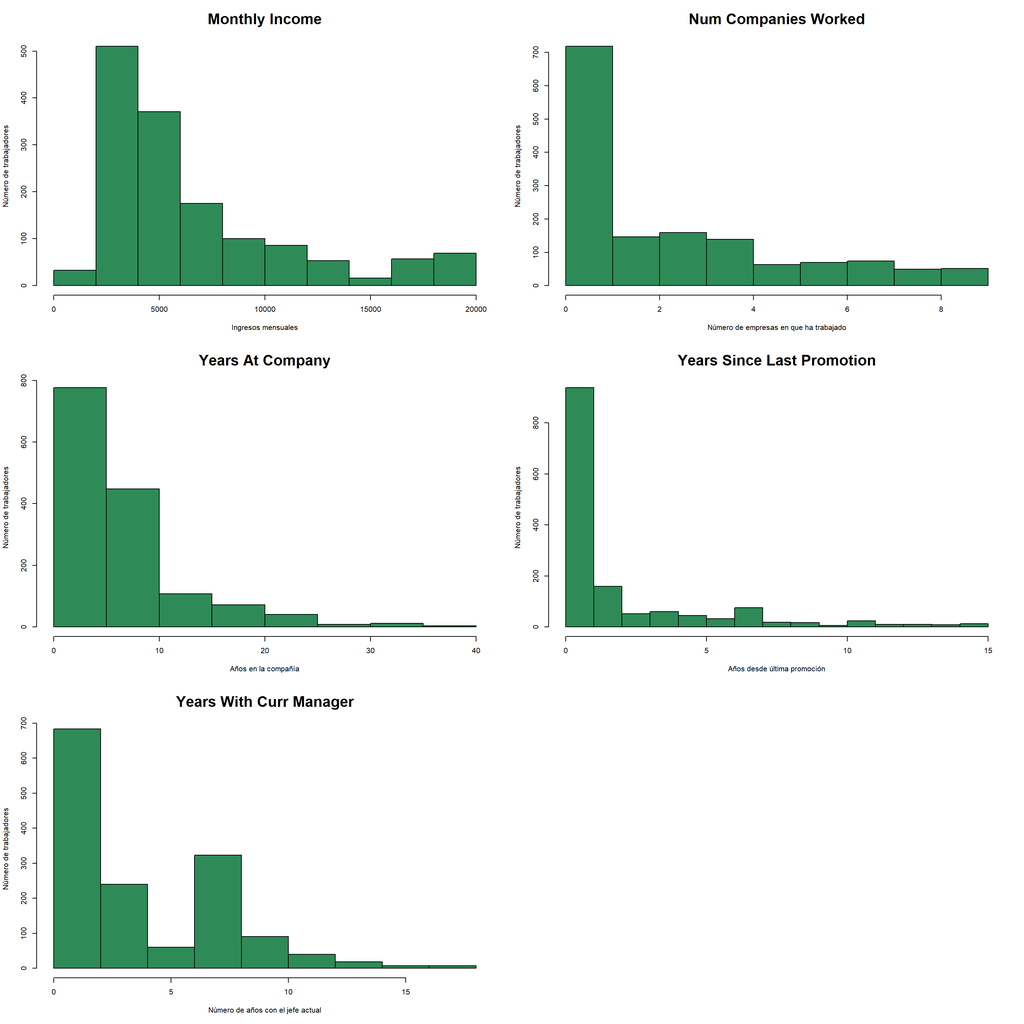

```r
par(mfrow = c(3, 2))
hist(df$MonthlyIncome, col = "seagreen", main = "Monthly Income", xlab = "Ingresos mensuales", ylab = "Número de trabajadores",cex.main=2)
hist(df$NumCompaniesWorked, col = "seagreen", main = "Num Companies Worked", xlab = "Número de empresas en que ha trabajado", ylab = "Número de trabajadores",cex.main=2)
hist(df$YearsAtCompany, col = "seagreen", main = "Years At Company", xlab = "Años en la compañía", ylab = "Número de trabajadores",cex.main=2)
hist(df$YearsSinceLastPromotion, col = "seagreen", main = "Years Since Last Promotion", xlab = "Años desde última promoción", ylab = "Número de trabajadores",cex.main=2)
hist(df$YearsWithCurrManager, col = "seagreen", main = "Years With Curr Manager", xlab = "Número de años con el jefe actual", ylab = "Número de trabajadores",cex.main=2)
```

Obtener cualquier agregación que el equipo considere relevante para negocio, y explicar el motivo y las conclusiones que se deducen.

Filtro por la varible Attrition

```r
Attrition_Yes = filter(datos,Attrition == "Yes")
Attrition_No = filter(datos,Attrition == "No")
head(Attrition_Yes)
```

```
##   Attrition    BusinessTravel Gender JobLevel MonthlyIncome NumCompaniesWorked
## 1       Yes     Travel_Rarely Female        2          5993                  8
## 2       Yes     Travel_Rarely   Male        1          2090                  6
## 3       Yes     Travel_Rarely   Male        1          2028                  5
## 4       Yes     Travel_Rarely   Male        1          3407                  7
## 5       Yes     Travel_Rarely   Male        1          2960                  2
## 6       Yes Travel_Frequently Female        1          3919                  1
##   YearsAtCompany YearsSinceLastPromotion YearsWithCurrManager
## 1              6                       0                    5
## 2              0                       0                    0
## 3              4                       0                    3
## 4              5                       0                    3
## 5              4                       1                    3
## 6             10                       6                    7
```

Podríamos estudiar los valores de salario mensual por género para comparar si existen diferencias.

• Para los empleados que dejan la empresa.

```r
by(Attrition_Yes$MonthlyIncome,(Attrition_Yes$Gender),FUN=summary)
```

```
## (Attrition_Yes$Gender): Female
##    Min. 1st Qu.  Median    Mean 3rd Qu.    Max.
##    1261    2401    2886    4770    5879   19845
## ------------------------------------------------------------
## (Attrition_Yes$Gender): Male
##    Min. 1st Qu.  Median    Mean 3rd Qu.    Max.
##    1009    2363    3408    4797    5894   19859
```

• Para los empleados que no dejan la empresa.

```r
by(Attrition_No$MonthlyIncome,(Attrition_No$Gender),FUN=summary)
```

```
## (Attrition_No$Gender): Female
##    Min. 1st Qu.  Median    Mean 3rd Qu.    Max.
##    1129    3452    5329    7019    9637   19973
## ------------------------------------------------------------
## (Attrition_No$Gender): Male
##    Min. 1st Qu.  Median    Mean 3rd Qu.    Max.
##    1051    3037    5075    6705    8480   19999
```

Observamos que para el grupo que deja el trabajo de media no hay mucha diferencia de salarios. Para los que no dejan el trabajo era evidente que los salarios serían mejores (y algo mejores para el género femenino según estos datos).

Número de compañias en las que el trabajador ha trabajado.

• Para los empleados que dejan la empresa.

```r
by(Attrition_Yes$NumCompaniesWorked,(Attrition_Yes$Gender),FUN=summary)
```

```
## (Attrition_Yes$Gender): Female
##    Min. 1st Qu.  Median    Mean 3rd Qu.    Max.
##   0.000   1.000   1.000   2.506   4.000   9.000
## ------------------------------------------------------------
## (Attrition_Yes$Gender): Male
##    Min. 1st Qu.  Median    Mean 3rd Qu.    Max.
##   0.000   1.000   2.000   3.193   5.750   9.000
```

• Para los empleados que no dejan la empresa.

```r
by(Attrition_No$NumCompaniesWorked,(Attrition_No$Gender),FUN=summary)
```

```
## (Attrition_No$Gender): Female
##    Min. 1st Qu.  Median    Mean 3rd Qu.    Max.
##   0.000   1.000   2.000   2.866   4.000   9.000
## ------------------------------------------------------------
## (Attrition_No$Gender): Male
##    Min. 1st Qu.  Median    Mean 3rd Qu.    Max.
##   0.000   1.000   1.000   2.495   4.000   9.000
```

Para este caso no existen grandes diferencias.

Años en la empresa.

• Para los empleados que dejan la empresa.

```r
by(Attrition_Yes$YearsAtCompany,(Attrition_Yes$Gender),FUN=summary)
```

```
## (Attrition_Yes$Gender): Female
##    Min. 1st Qu.  Median    Mean 3rd Qu.    Max.
##    0.00    1.00    4.00    5.92    8.00   40.00
## ------------------------------------------------------------
## (Attrition_Yes$Gender): Male
##    Min. 1st Qu.  Median    Mean 3rd Qu.    Max.
##   0.000   1.000   3.000   4.673   6.750  31.000
```

• Para los empleados que no dejan la empresa.

```r
by(Attrition_No$YearsAtCompany,(Attrition_No$Gender),FUN=summary)
```

```
## (Attrition_No$Gender): Female
##    Min. 1st Qu.  Median    Mean 3rd Qu.    Max.
##   0.000   3.000   6.000   7.459  10.000  29.000
## ------------------------------------------------------------
## (Attrition_No$Gender): Male
##    Min. 1st Qu.  Median    Mean 3rd Qu.    Max.
##   0.000   3.000   5.000   7.307  10.000  37.000
```

Años desde la última promoción.

• Para los empleados que dejan la empresa.

```r
by(Attrition_Yes$YearsSinceLastPromotion,(Attrition_Yes$Gender),FUN=summary)
```

```
## (Attrition_Yes$Gender): Female
##    Min. 1st Qu.  Median    Mean 3rd Qu.    Max.
##   0.000   0.000   1.000   2.034   2.000  15.000
## ------------------------------------------------------------
## (Attrition_Yes$Gender): Male
##    Min. 1st Qu.  Median    Mean 3rd Qu.    Max.
##   0.000   0.000   1.000   1.893   2.000  14.000
```

• Para los empleados que no dejan la empresa.

```r
by(Attrition_No$YearsSinceLastPromotion,(Attrition_No$Gender),FUN=summary)
```

```
## (Attrition_No$Gender): Female
##    Min. 1st Qu.  Median    Mean 3rd Qu.    Max.
##   0.000   0.000   1.000   2.339   3.000  15.000
## ------------------------------------------------------------
## (Attrition_No$Gender): Male
##    Min. 1st Qu.  Median    Mean 3rd Qu.    Max.
##   0.000   0.000   1.000   2.163   2.000  15.000
```

Años con el mismo jefe.

• Para los empleados que dejan la empresa.

```r
by(Attrition_Yes$YearsWithCurrManager,(Attrition_Yes$Gender),FUN=summary)
```

```
## (Attrition_Yes$Gender): Female
##    Min. 1st Qu.  Median    Mean 3rd Qu.    Max.
##   0.000   0.000   2.000   3.241   7.000  14.000
## ------------------------------------------------------------
## (Attrition_Yes$Gender): Male
##    Min. 1st Qu.  Median    Mean 3rd Qu.    Max.
##   0.000   0.000   2.000   2.627   4.000  14.000
```

• Para los empleados que no dejan la empresa.

```r
by(Attrition_No$YearsWithCurrManager,(Attrition_No$Gender),FUN=summary)
```

```
## (Attrition_No$Gender): Female
##    Min. 1st Qu.  Median    Mean 3rd Qu.    Max.
##   0.000   2.000   3.000   4.433   7.000  17.000
## ------------------------------------------------------------
## (Attrition_No$Gender): Male
##    Min. 1st Qu.  Median    Mean 3rd Qu.    Max.
##   0.000   2.000   3.000   4.322   7.000  17.000
```

Buscar correlaciones y explicarlas, desde el punto de vista de negocio.

```r
head(datos)
```

```
##   Attrition    BusinessTravel Gender JobLevel MonthlyIncome NumCompaniesWorked
## 1       Yes     Travel_Rarely Female        2          5993                  8
## 2        No Travel_Frequently   Male        2          5130                  1
## 3       Yes     Travel_Rarely   Male        1          2090                  6
## 4        No Travel_Frequently Female        1          2909                  1
## 5        No     Travel_Rarely   Male        1          3468                  9
## 6        No Travel_Frequently   Male        1          3068                  0
##   YearsAtCompany YearsSinceLastPromotion YearsWithCurrManager
## 1              6                       0                    5
## 2             10                       1                    7
## 3              0                       0                    0
## 4              8                       3                    0
## 5              2                       2                    2
## 6              7                       3                    6
```

```r
datos_num <- select(datos, JobLevel, MonthlyIncome, NumCompaniesWorked, YearsAtCompany, YearsSinceLastPromotion, YearsWithCurrManager)
cor(datos_num)
```

```
##                          JobLevel MonthlyIncome NumCompaniesWorked
## JobLevel                1.0000000     0.9502999         0.14250112
## MonthlyIncome           0.9502999     1.0000000         0.14951522
## NumCompaniesWorked      0.1425011     0.1495152         1.00000000
## YearsAtCompany          0.5347387     0.5142848        -0.11842134
## YearsSinceLastPromotion 0.3538853     0.3449776        -0.03681389
## YearsWithCurrManager    0.3752806     0.3440789        -0.11031916
##                         YearsAtCompany YearsSinceLastPromotion
## JobLevel                     0.5347387              0.35388535
## MonthlyIncome                0.5142848              0.34497764
## NumCompaniesWorked          -0.1184213             -0.03681389
## YearsAtCompany               1.0000000              0.61840887
## YearsSinceLastPromotion      0.6184089              1.00000000
## YearsWithCurrManager         0.7692124              0.51022364
##                         YearsWithCurrManager
## JobLevel                           0.3752806
## MonthlyIncome                      0.3440789
## NumCompaniesWorked                -0.1103192
## YearsAtCompany                     0.7692124
## YearsSinceLastPromotion            0.5102236
## YearsWithCurrManager               1.0000000
```

Con esta tabla resumen podemos explicar las correlaciones desde el punto de vista del negocio.

• Por ejemplo, si tomamos la primera columna, vemos que a el nivel de jerarquía en la empresa está intimamente relacionada con los ingresos mensuales, con la antiguedad en la empresa algo menos, y en menor medida con los años desde la última promoción y los años con el mismo jefe. • Los años en la compañía está muy relacionada con haber tenido mucho tiempo al mismo jefe. • Los años desde la última promoción con el número de años que se lleva trabanjado en la empresa.

También podemos representar la matriz graficamente.

```r
library(GGally)
```

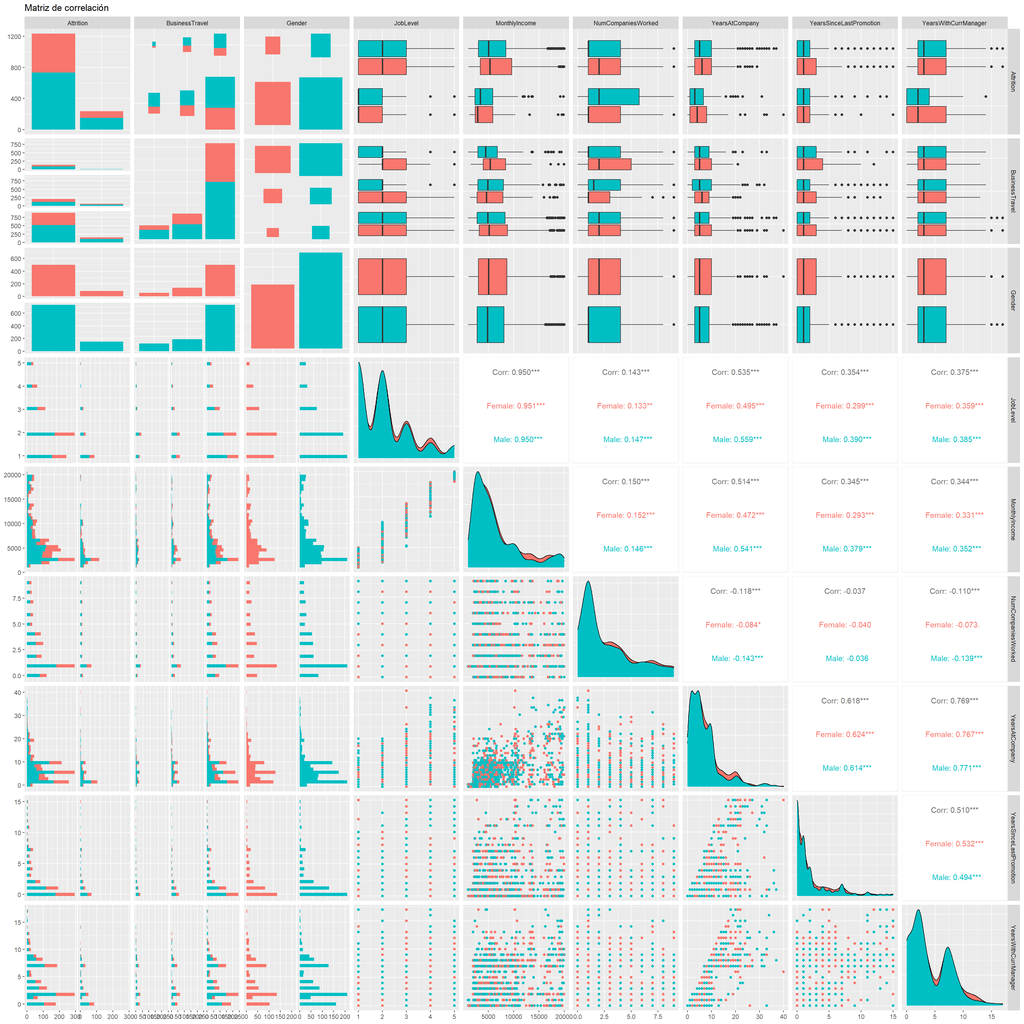

```r
ggpairs(datos, title="Matriz de correlación",cex.main=10, aes(colour = Gender))
```

Representar gráficamente algunas medidas de dispersión (boxplots por grupos, histogramas de una o varias variables, incluidos histogramas de una misma variable separada en función de otra, gráficos de dispersión, etc). No es necesario obtener gráficos impresionantes; se valorará mucho más la explicación acerca de las conclusiones que se desprenden del gráfico. Imprescindible que incluyan ejes con marcas visibles y etiquetas indicando qué se representa y en qué unidades está expresado.

Graficamos para comparar

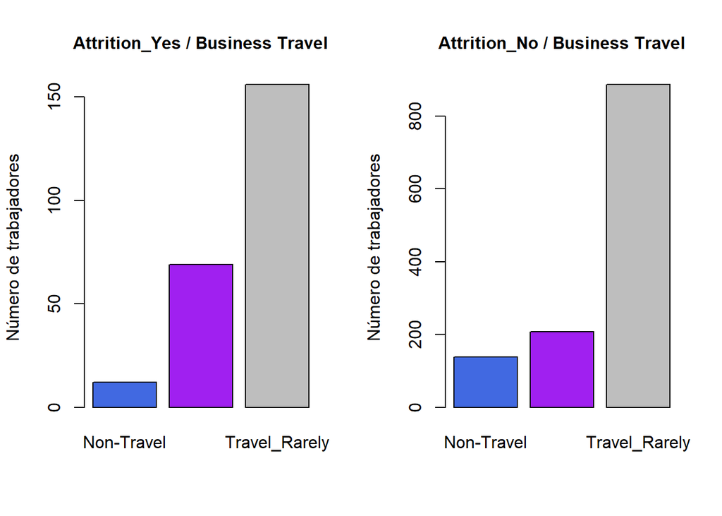

```r
par(mfrow = c(1, 2))
barplot(table(Attrition_Yes$BusinessTravel), col = c("royalblue", "purple", "grey"), main = "Attrition_Yes / Business Travel",cex.main=1, ylab = "Número de trabajadores")
barplot(table(Attrition_No$BusinessTravel), col = c("royalblue", "purple", "grey"), main = "Attrition_No / Business Travel",cex.main=1, ylab = "Número de trabajadores")
```

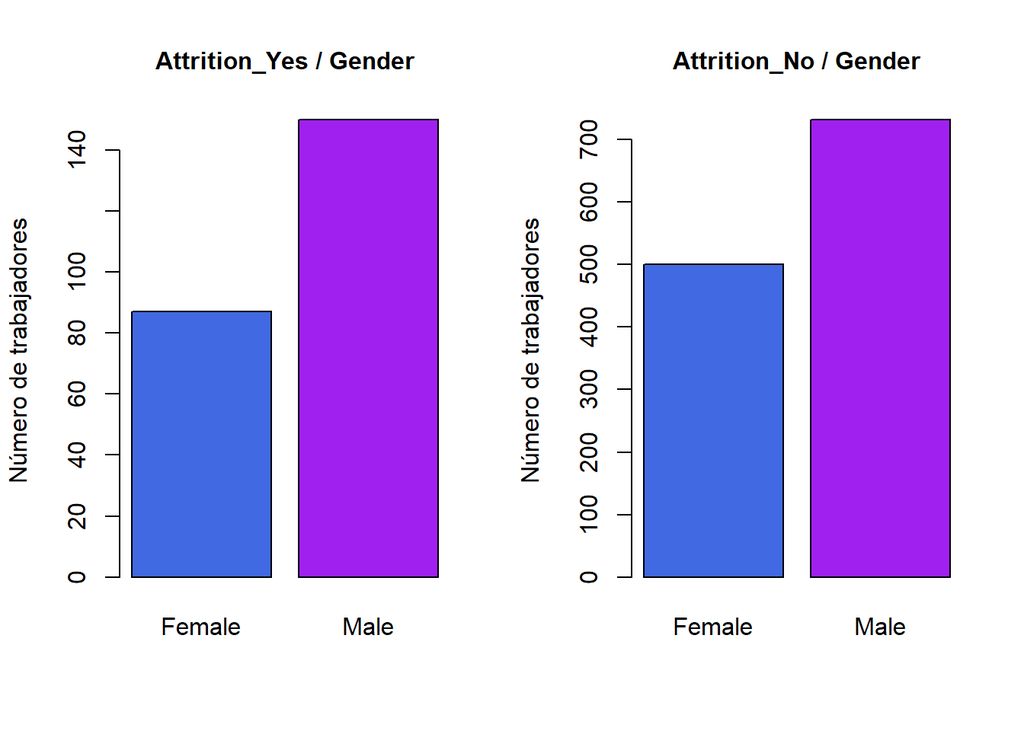

```r
par(mfrow = c(1, 2))
barplot(table(Attrition_Yes$Gender), col = c("royalblue", "purple"), main = "Attrition_Yes / Gender",cex.main=1, ylab = "Número de trabajadores")
barplot(table(Attrition_No$Gender), col = c("royalblue", "purple"), main = "Attrition_No / Gender",cex.main=1, ylab = "Número de trabajadores")
```

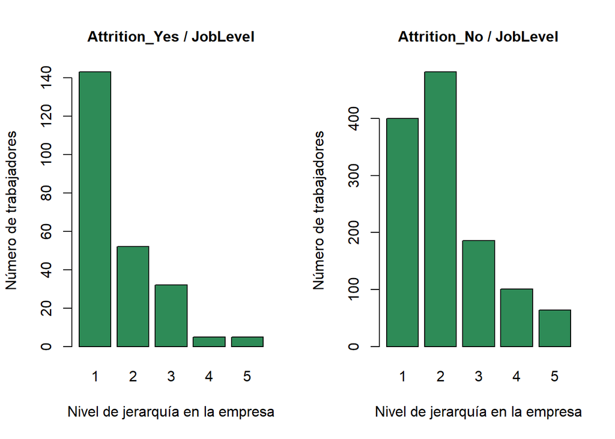

```r
par(mfrow = c(1, 2))
barplot(table(Attrition_Yes$JobLevel), col = "seagreen", main = "Attrition_Yes / JobLevel",cex.main=1, xlab = "Nivel de jerarquía en la empresa", ylab = "Número de trabajadores")
barplot(table(Attrition_No$JobLevel), col = "seagreen", main = "Attrition_No / JobLevel",cex.main=1, xlab = "Nivel de jerarquía en la empresa",ylab = "Número de trabajadores")
```

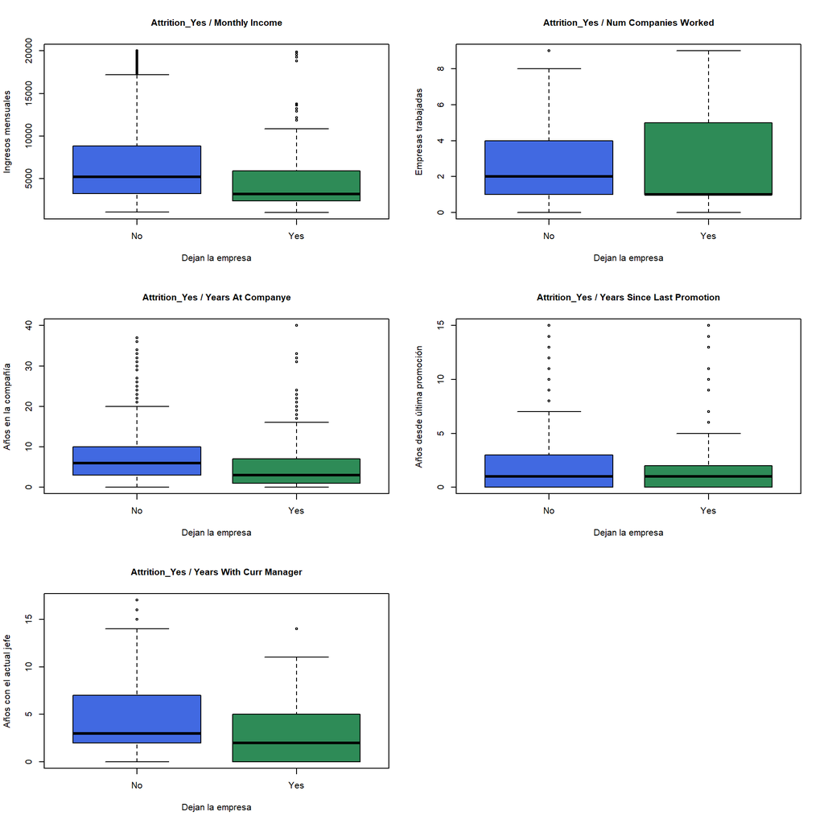

```r
par(mfrow=c(3, 2))
boxplot(datos$MonthlyIncome~datos$Attrition, col = c("royalblue", "seagreen"), main = "Attrition_Yes / Monthly Income",cex.main=1, xlab = "Dejan la empresa", ylab="Ingresos mensuales")
boxplot(datos$NumCompaniesWorked~datos$Attrition, col = c("royalblue", "seagreen"), main = "Attrition_Yes / Num Companies Worked",cex.main=1, xlab = "Dejan la empresa", ylab="Empresas trabajadas")
boxplot(datos$YearsAtCompany~datos$Attrition, col = c("royalblue", "seagreen"), main = "Attrition_Yes / Years At Companye",cex.main=1,xlab = "Dejan la empresa", ylab="Años en la compañía")
boxplot(datos$YearsSinceLastPromotion~datos$Attrition, col = c("royalblue", "seagreen"), main = "Attrition_Yes / Years Since Last Promotion",cex.main=1,xlab = "Dejan la empresa", ylab="Años desde última promoción")
boxplot(datos$YearsWithCurrManager~datos$Attrition, col =  c("royalblue", "seagreen"), main = "Attrition_Yes / Years With Curr Manager",cex.main=1,xlab = "Dejan la empresa", ylab="Años con el actual jefe")
```

Comparo los años en la empresa en función con los ingresos al mes, con los años teniendo al mismo jefe y la jerarquía en al empresa en función de los años en la misma. Calculos también sus regresiones.

```r
regresion_ingresos <- lm(datos$MonthlyIncome~datos$YearsAtCompany, datos)
summary(regresion_ingresos)
```

```
##
## Call:
## lm(formula = datos$MonthlyIncome ~ datos$YearsAtCompany, data = datos)
##
## Residuals:
##    Min     1Q Median     3Q    Max
##  -9504  -2499  -1188   1393  15484
##
## Coefficients:
##                      Estimate Std. Error t value Pr(>|t|)
## (Intercept)            3733.3      160.1   23.32   <2e-16 ***
## datos$YearsAtCompany    395.2       17.2   22.98   <2e-16 ***
## ---
## Signif. codes:  0 '***' 0.001 '**' 0.01 '*' 0.05 '.' 0.1 ' ' 1
##
## Residual standard error: 4039 on 1468 degrees of freedom
## Multiple R-squared:  0.2645, Adjusted R-squared:  0.264
## F-statistic: 527.9 on 1 and 1468 DF,  p-value: < 2.2e-16
```

```r
regresion_jefe <- lm(datos$YearsWithCurrManager~datos$YearsAtCompany, datos)
summary(regresion_jefe)
```

```
##
## Call:
## lm(formula = datos$YearsWithCurrManager ~ datos$YearsAtCompany,
##     data = datos)
##
## Residuals:
##      Min       1Q   Median       3Q      Max
## -15.7674  -1.4315  -0.2235   1.5365   7.9526
##
## Coefficients:
##                      Estimate Std. Error t value Pr(>|t|)
## (Intercept)          0.983505   0.090402   10.88   <2e-16 ***
## datos$YearsAtCompany 0.447995   0.009713   46.12   <2e-16 ***
## ---
## Signif. codes:  0 '***' 0.001 '**' 0.01 '*' 0.05 '.' 0.1 ' ' 1
##
## Residual standard error: 2.281 on 1468 degrees of freedom
## Multiple R-squared:  0.5917, Adjusted R-squared:  0.5914
## F-statistic:  2127 on 1 and 1468 DF,  p-value: < 2.2e-16
```

```r
regresion_Level <- lm(datos$JobLevel~datos$YearsAtCompany, datos)
summary(regresion_Level)
```

```
##
## Call:
## lm(formula = datos$JobLevel ~ datos$YearsAtCompany, data = datos)
##
## Residuals:
##     Min      1Q  Median      3Q     Max
## -2.3192 -0.6767 -0.2395  0.4876  3.6132
##
## Coefficients:
##                      Estimate Std. Error t value Pr(>|t|)
## (Intercept)          1.386841   0.037088   37.39   <2e-16 ***
## datos$YearsAtCompany 0.096617   0.003985   24.25   <2e-16 ***
## ---
## Signif. codes:  0 '***' 0.001 '**' 0.01 '*' 0.05 '.' 0.1 ' ' 1
##
## Residual standard error: 0.9357 on 1468 degrees of freedom
## Multiple R-squared:  0.2859, Adjusted R-squared:  0.2855
## F-statistic: 587.9 on 1 and 1468 DF,  p-value: < 2.2e-16
```

[figure not shown]

```r
par(mfrow=c(3, 2))
plot(datos$MonthlyIncome~datos$YearsAtCompany, main="MonthlyIncome / YearsAtCompany", ylab="Ingresos mensuales", xlab="Años en la empresa",cex.main=1, col = "red",cex.main=2, cex.lab=1.5)
abline(regresion_ingresos, col = "blue")
plot(datos$YearsWithCurrManager~datos$YearsAtCompany, main="YearsWithCurrManager / YearsAtCompany", ylab="Ingresos mensuales", xlab="Años con el mismo jefe",cex.main=1, col = "red",cex.main=2, cex.lab=1.5)
abline(regresion_jefe, col = "blue")
plot(datos$JobLevel~datos$YearsAtCompany, main="JobLevel / YearsAtCompany", ylab="Jerarquía en la empresa", xlab="Años en la empresa",cex.main=1, col = "red", cex.axis = 1,cex.main=2, cex.lab=1.5)
abline(regresion_Level, col = "blue")
```